# Assignment Week 04

Laurin Schaller

2023-03-18

# Loading libraries

```r
suppressPackageStartupMessages({
  library(AnnotationHub)
  library(rtracklayer)
  library(epiwraps)
  library(GenomicRanges)
})
ah <- AnnotationHub()
```

```
## snapshotDate(): 2022-10-31
```

# Data

All data chosen is from the same sets of experiments for consistency

- Mus musculus strain Bruce4 ES-Bruce4 cell line
- Bing Ren, UCSD

```r
options(timeout = max(999999, getOption("timeout")))
download.file("https://www.ncbi.nlm.nih.gov/geo/download/?acc=GSM918750&format=file&file=GSM918750%5Fmm9%5FwgEncodeLicrTfbsEsb4P300ME0C57bl6StdPk%2EbroadPeak%2Egz", "encode/ep300.broadpeak.gz")
download.file("https://www.ncbi.nlm.nih.gov/geo/download/?acc=GSM769008&format=file&file=GSM769008%5FwgEncodeLicrHistoneEsb4H3k4me3ME0C57bl6StdPk%2EbroadPeak%2Egz", "encode/H3K4me3.broadpeak.gz")
download.file("https://www.ncbi.nlm.nih.gov/geo/download/?acc=GSM769009&format=file&file=GSM769009%5FwgEncodeLicrHistoneEsb4H3k4me1ME0C57bl6StdPk%2EbroadPeak%2Egz", "encode/H3K4me1.broadpeak.gz")
download.file("https://www.ncbi.nlm.nih.gov/geo/download/?acc=GSM1000099&format=file&file=GSM1000099%5Fmm9%5FwgEncodeLicrHistoneEsb4H3k27acME0C57bl6StdPk%2EbroadPeak%2Egz", "encode/H3K27ac.broadpeak.gz")
download.file("https://www.ncbi.nlm.nih.gov/geo/download/?acc=GSM1000089&format=file&file=GSM1000089%5Fmm9%5FwgEncodeLicrHistoneEsb4H3k27me3ME0C57bl6StdPk%2EbroadPeak%2Egz", "encode/H3K27me3.broadpeak.gz")
```

We have to use command line to unzip gz files

```bash
gunzip "encode/ep300.broadpeak.gz"
gunzip "encode/H3K4me3.broadpeak.gz"
gunzip "encode/H3K4me1.broadpeak.gz"
gunzip "encode/H3K27ac.broadpeak.gz"
gunzip "encode/H3K27me3.broadpeak.gz"
```

```r
list.files(path="encode/")
```

```
## [1] "ep300.broadpeak"    "H3K27ac.broadpeak"  "H3K27me3.broadpeak"
## [4] "H3K4me1.broadpeak"  "H3K4me3.broadpeak"
```

Files are looking good and are unzipped. Now we can load them

# Loading peaks

```r
peaksep300 <- rtracklayer::import("encode/ep300.broadpeak")
peaksH3K4me3<- rtracklayer::import("encode/H3K4me3.broadpeak")
peaksH3K4me1 <- rtracklayer::import("encode/H3K4me1.broadpeak")
peaksH3K27ac <- rtracklayer::import("encode/H3K27ac.broadpeak")
peaksH3K27me3 <- rtracklayer::import("encode/H3K27me3.broadpeak")
```

```r
head(peaksep300)
```

```
## GRanges object with 6 ranges and 5 metadata columns:
##       seqnames          ranges strand |        name     score signalValue
##          <Rle>       <IRanges>  <Rle> | <character> <numeric>   <numeric>
##   [1]     chr1 3052565-3053564      * |        <NA>       300           3
##   [2]     chr1 3472283-3473282      * |        <NA>      1000          10
##   [3]     chr1 3943290-3944289      * |        <NA>       500           5
##   [4]     chr1 3984468-3985467      * |        <NA>       400           4
##   [5]     chr1 4140529-4141528      * |        <NA>       600           6
##   [6]     chr1 4533810-4534809      * |        <NA>       300           3
##          pValue    qValue
##       <numeric> <numeric>
##   [1]        -1        -1
##   [2]        -1        -1
##   [3]        -1        -1
##   [4]        -1        -1
##   [5]        -1        -1
##   [6]        -1        -1
##   -------
##   seqinfo: 21 sequences from an unspecified genome; no seqlengths
```

# Checking for overlaps

```r
p300OverlapsH3K4me3 <- overlapsAny(peaksep300, peaksH3K4me3)
p300OverlapsH3K4me1 <- overlapsAny(peaksep300, peaksH3K4me1)
p300OverlapsH3K27ac <- overlapsAny(peaksep300, peaksH3K27ac)
p300OverlapsH3K27me3 <- overlapsAny(peaksep300, peaksH3K27me3)
```

```r
head(p300OverlapsH3K4me3)
```

```
## [1] FALSE FALSE FALSE FALSE FALSE FALSE
```

```r
ol1 <- table(p300OverlapsH3K4me1)
ol1
```

```
## p300OverlapsH3K4me1
## FALSE  TRUE
##  5203 18451
```

```r
ol2 <- table(p300OverlapsH3K4me3)
ol2
```

```
## p300OverlapsH3K4me3
## FALSE  TRUE
## 17483  6171
```

```r
ol3 <- table(p300OverlapsH3K27ac)
ol3
```

```
## p300OverlapsH3K27ac
## FALSE  TRUE
## 11354 12300
```

```r
ol4 <- table(p300OverlapsH3K27me3)
ol4
```

```
## p300OverlapsH3K27me3
## FALSE  TRUE
## 23212   442
```

# Overlap data exploration

```r
totalOl <- sum(ol1[2], ol2[2], ol3[2], ol4[2])
totalOl
```

```
## [1] 37364
```

```r
ol1[2]/totalOl * 100
```

```
##     TRUE
## 49.38176
```

```r
ol2[2]/totalOl * 100
```

```
##    TRUE
## 16.5159
```

```r
ol3[2]/totalOl * 100
```

```
##     TRUE
## 32.91939
```

```r
ol4[2]/totalOl * 100
```

```
##     TRUE
## 1.182957
```

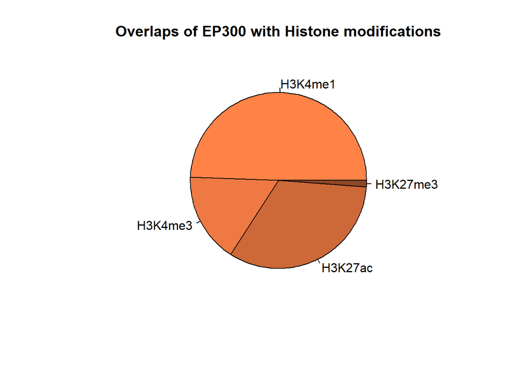

```r
sumOverlaps <- c(ol1[2], ol2[2], ol3[2], ol4[2])
OlLabels <- c("H3K4me1", "H3K4me3", "H3K27ac", "H3K27me3")
pie(sumOverlaps, OlLabels, main="Overlaps of EP300 with Histone modifications", col = c("sienna1", "sienna2", "sienna3", "sienna4"))
```

Let’s see where we have the most overlaps of EP300 with the four histone modifications. Also let’s make it pretty. As we can see from the pie chart close to half of the overlaps are with H3K4me1 and there are almost no overlaps with H3K27me3.

- The total overlaps are: 37364
- 49.38176% of overlaps are with H3K4me1
- 16.5159% of overlaps are with H3K4me3
- 32.91939% of overlaps are with H3K27ac
- 1.182957% of overlaps are with H3K27me3

# Biological background and interpretation

From the uniprot.org description of EP300:

- Functions as histone acetyltransferase and regulates transcription via chromatin remodeling. Acetylates all four core histones in nucleosomes.

From this the results in this analysis are a bit surprising to me. If it acetylates histones it makes sense that it interacts with methylated histones. But why is there such a big proportion of overlaps with H3K27ac? Also the proportion of overlaps with H3K27me3 are rather small.